# Oceanographic variables

Masumbuko Semba

1/13/2020

## Expedition of June 2018

Create a section of the CTD station casted in June 2018

subset only the cast north of Mafia Island and smooth profiles to a standard depth of 2 meters. You can can simply change the standard depth that represent the situation on the ground

The plot the location of the CTD cast

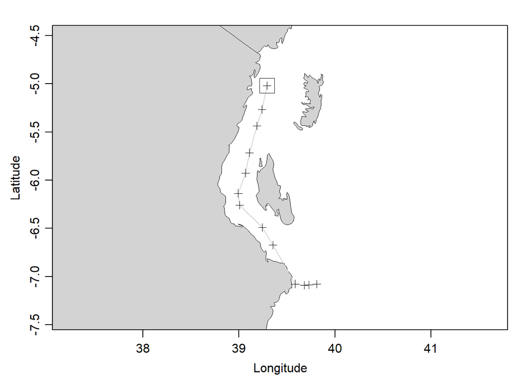

We notice that there are thirteen casts made during the June 2018 Expedition. Once we have picked only the ctd cast of interest, we need to convert the section to a data frame, a format that other programs can read. We first need to convert the section back to a list

Because there are thirteen stations, we simply use `for` loop function to iterate the process. The whole process will create a tibble files that contains all the stations and their variable that associated with depth.

We can check whether we can confirm the four stations that form a transect just off Kimbiji

```
## # A tibble: 4 x 1
##   station
##   <chr>
## 1 AM00891
## 2 AM00892
## 3 AM00893
## 4 AM00894
```

We can now plot the sections of some variables for the the transect off Kimbiji

[output not shown]

[output not shown]

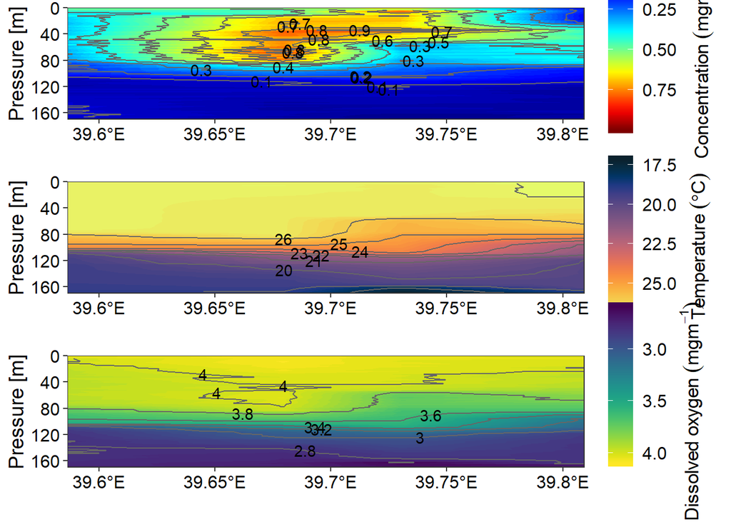

## Expedition of November 2017

Create a section of the CTD station casted in November 2017

subset only the cast north of Mafia Island and smooth profiles to a standard depth of 2 meters. You can can simply change the standard depth that represent the situation on the ground

The plot the location of the CTD cast

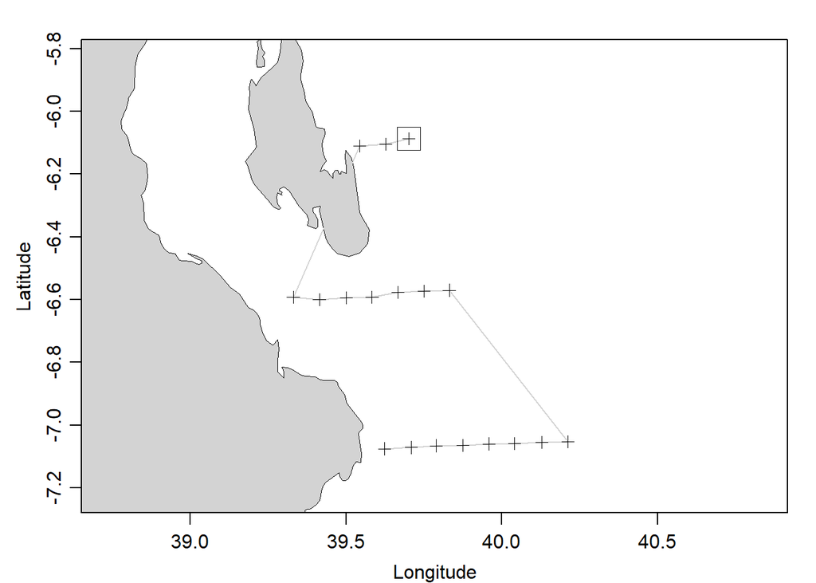

We notice that this expedition casted in the deep water and there are three transects—off Chwaka, South of Kizimkazi and off Kimbiji. Once we have picked only the ctd cast of interest, we need to convert the section to a data frame, a format that other programs can read. We first need to convert the section back to a list

Because there are eighteen stations, we simply use `for` loop function to iterate the process. The whole process will create a tibble files that contains all the stations and their variable that associated with standard depth.

We can check whether we can confirm the eight stations that form a transect just off Kimbiji for 2017 expedition

```
## # A tibble: 8 x 1
##   station
##   <chr>
## 1 AM00782
## 2 AM00783
## 3 AM00784
## 4 AM00785
## 5 AM00786
## 6 AM00787
## 7 AM00788
## 8 AM00789
```

We can now plot the sections of some variables for the the transect off Kimbiji

[output not shown]

[output not shown]

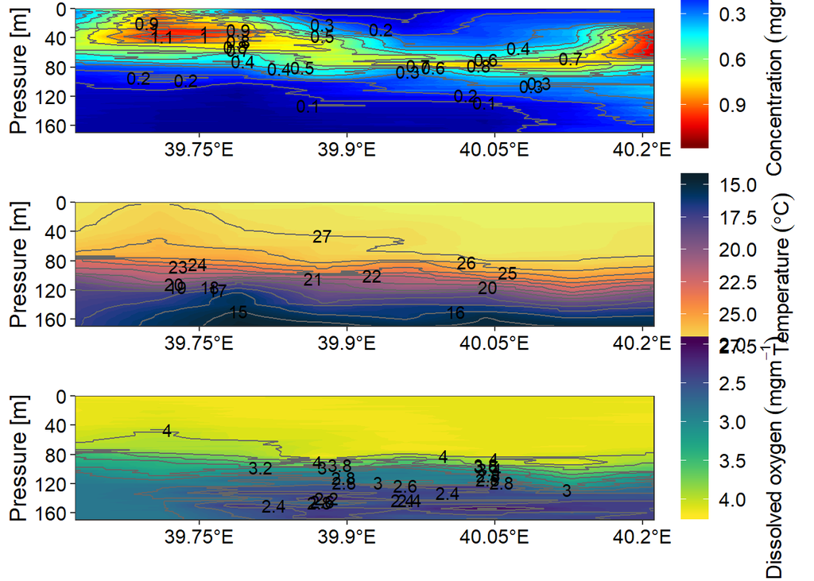

## Expedition of August 2004

notice that the algoa folder contain both upcast and downcast, to create a list of files in the directory, I used the `dstn` instead of `.cnv` extension to only pull the file that recorded the downcast profiles.

Create a section of the CTD station casted in August 2004 with Algoa cruise

subset only the cast north of Mafia Island and smooth profiles to a standard depth of 2 meters. You can can simply change the standard depth that represent the situation on the ground

The plot the location of the CTD cast

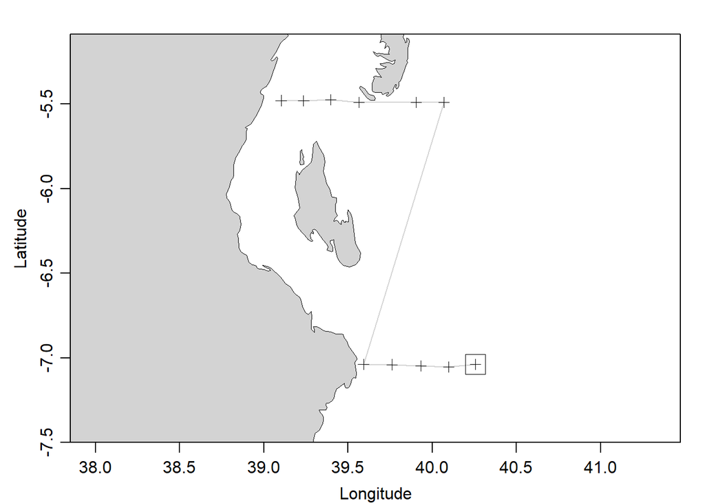

We notice that this expedition casted in the deep water and shallow areas with a total of two transects—Pemba channel and off Kimbiji. Once we have picked only the ctd cast of interest, we need to convert the section to a data frame, a format that other programs can read. We first need to convert the section back to a list

We can check whether we can confirm the five stations that form a transect just off Kimbiji for 2004 expedition

```
## # A tibble: 5 x 1
##   station
##   <chr>
## 1 C08743
## 2 C08744
## 3 C08745
## 4 C08746
## 5 C08747
```

We can now plot the sections of some variables for the the transect off Kimbiji

[output not shown]

[output not shown]

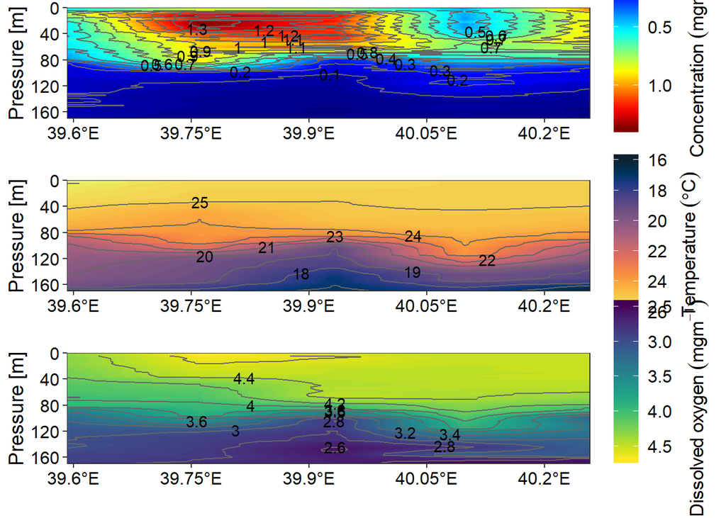

We can now plot the sections of some variables for the the transect In the Pemba channel

[output not shown]

[output not shown]

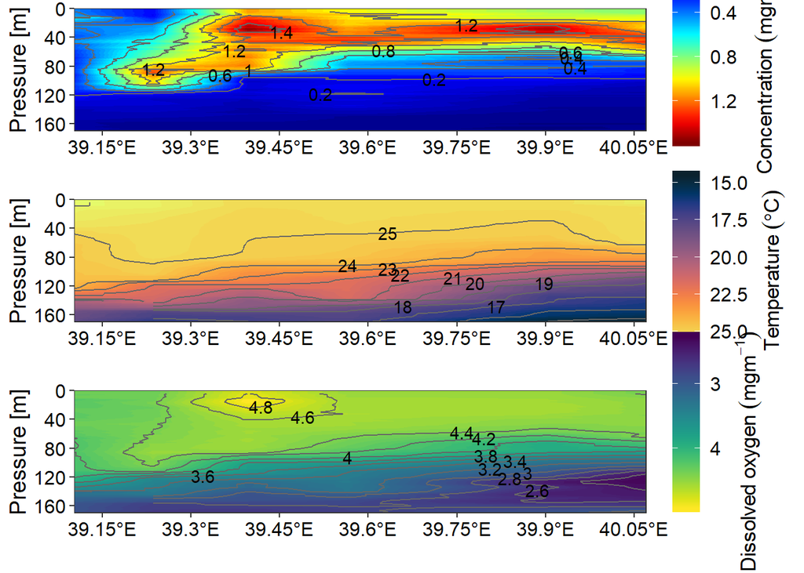